# Sentinel-2 L2A

[figure not shown]

#### Index

- Overview
- Setup (imports, defaults, dask, odc)
- Example query
- Product definition
- Quality layer
- Create and apply a good quality pixel mask
- Plot and browse the data

## Overview

Sentinel-2 is an Earth observation mission from the EU Copernicus Programme that systematically acquires optical imagery at high spatial resolution (up to 10 m for some bands). The mission is a constellation of two identical satellites in the same orbit, 180° apart for optimal coverage and data delivery. Together, they cover all Earth's land surfaces, large islands, inland and coastal waters every 3-5 days.

Sentinel-2A was launched on 23 June 2015 and Sentinel-2B followed on 7 March 2017. Both of the Sentinel-2 satellites carry a wide swath high-resolution multispectral imager with 13 spectral bands. For more information see:

- [ESA Sentinel missions](https://www.esa.int/Applications/Observing_the_Earth/Copernicus/The_Sentinel_missions)
- [Sentinel-2 technical specifications](https://sentinels.copernicus.eu/web/sentinel/technical-guides/sentinel-2-msi)

*Selected text adapted from https://github.com/GeoscienceAustralia/dea-notebooks/blob/develop/DEA_datasets/Sentinel_2.ipynb*

#### Data source and documentation

ESA produces a surface reflectance "S2 L2A" product using their [sen2cor](https://step.esa.int/main/snap-supported-plugins/sen2cor/) software. [Element84](https://github.com/Element84/earth-search) convert these data to Cloud-Optimized Geotiff format and makes them publicly available at their [Earth Search STAC API](https://earth-search.aws.element84.com/v1) endpoint, and [AWS open data](https://registry.opendata.aws/sentinel-2-l2a-cogs/), for programmatic access.

EASI uses its STAC indexing tools to index datasets into our ODC databases.

[output not shown]

#### Baseline processing and offset consideration

ESA introduced a change to their L1C processing (processing baseline >=04.00, for data since 25 January 2022) that encodes their L1C and L2A products with an *offset* value such that `phyiscal_value = encoded_value * scale_factor + offset`

Element84 additionally [may have pre-applied the offset or not](https://github.com/Element84/earth-search/issues/23#issuecomment-1834674853) to the data that we index and load. This introduces an inconsistency in the S2A series that we need to account for.

In this notebook we show how to correctly load `s2_l2a` data with the offset applied to scenes where required. We use a `load_s2l2a_with_offset` function provided in `easi_tools` that identifies which scenes within a query should and should not have the offset applied, loads the data and applies the offset, and combines the non-offsetted with the offsetted scenes into a single xarray Dataset. This method also applies the scale_factor to all data in the query.

## Setup

#### Imports

```python
# Common imports and settings
import os, sys, re
from pathlib import Path
from IPython.display import Markdown
import pandas as pd
pd.set_option("display.max_rows", None)
import xarray as xr

# Datacube
import datacube
from datacube.utils.aws import configure_s3_access
import odc.geo.xr                                  # https://github.com/opendatacube/odc-geo
from datacube.utils import masking  # https://github.com/opendatacube/datacube-core/blob/develop/datacube/utils/masking.py
from odc.algo import enum_to_bool                  # https://github.com/opendatacube/odc-tools/blob/develop/libs/algo/odc/algo/_masking.py
from dea_tools.plotting import display_map, rgb    # https://github.com/GeoscienceAustralia/dea-notebooks/tree/develop/Tools

# Basic plots
%matplotlib inline
# import matplotlib.pyplot as plt
# plt.rcParams['figure.figsize'] = [12, 8]

# Holoviews
# https://holoviz.org/tutorial/Composing_Plots.html
# https://holoviews.org/user_guide/Composing_Elements.html
import hvplot.pandas
import hvplot.xarray
import panel as pn
import colorcet as cc
import cartopy.crs as ccrs
from datashader import reductions
from holoviews import opts
# hv.extension('bokeh', logo=False)
```

```python
# EASI defaults
# These are convenience functions so that the notebooks in this repository work in all EASI deployments

# The `git.Repo()` part returns the local directory that easi-notebooks has been cloned into
# If using the `easi-tools` functions from another path, replace `repo` with your local path to `easi-notebooks` directory
try:
    import git
    repo = git.Repo('.', search_parent_directories=True).working_tree_dir    # Path to this cloned local directory
except (ImportError, git.InvalidGitRepositoryError):
    repo = Path.home() / 'easi-notebooks'    # Reasonable default
    if not repo.is_dir():
        raise RuntimeError('To use `easi-tools` please provide the local path to `https://github.com/csiro-easi/easi-notebooks`')
if repo not in sys.path:
    sys.path.append(str(repo))    # Add the local path to `easi-notebooks` to python

from easi_tools import EasiDefaults
from easi_tools import initialize_dask, xarray_object_size, mostcommon_crs, heading
from easi_tools.load_s2l2a import load_s2l2a_with_offset
```

#### EASI defaults

These default values are configured for each EASI instance. They help us to use the same training notebooks in each EASI instance. You may find some of the functions convenient for your work or you can easily override the values in your copy of this notebook.

```python
easi = EasiDefaults()

family = 'sentinel-2'
product = 's2_l2a'   # Sentinel-2 collection 0, L2A
display(Markdown(f'Default {family} product for "{easi.name}": [{product}]({easi.explorer}/products/{product})'))
```

```
Successfully found configuration for deployment "asia"
```

Default sentinel-2 product for "asia": s2_l2a

#### Dask cluster

Using a local *Dask* cluster is a good habit to get into. It can simplify loading and processing of data in many cases, and it provides a dashboard that shows the loading/processing progress.

To learn more about *Dask* see the set of [dask notebooks](https://github.com/csiro-easi/easi-notebooks/tree/main/html#dask-tutorials).

```python
# Local cluster
cluster, client = initialize_dask(workers=4)
display(client)

# Or use Dask Gateway - this may take a few minutes
# cluster, client = initialize_dask(use_gateway=True, workers=4)
# display(client)
```

```
Successfully found configuration for deployment "asia"
```

Client

Client-b2abba13-b1c8-11ef-89a3-0e10825650b1

| **Connection method:** Cluster object | **Cluster type:** distributed.LocalCluster |
| --- | --- |
| **Dashboard:** https://hub.asia.easi-eo.solutions/user/pag064/proxy/39615/status |  |

**Cluster Info**

LocalCluster

e3e9f7aa

| **Dashboard:** https://hub.asia.easi-eo.solutions/user/pag064/proxy/39615/status | **Workers:** 4 |
| --- | --- |
| **Total threads:** 8 | **Total memory:** 24.00 GiB |
| **Status:** running | **Using processes:** True |

**Scheduler Info**

Scheduler

Scheduler-e1823c0a-bb93-4f44-9f16-7116bd7cb226

| **Comm:** tcp://127.0.0.1:43171 | **Workers:** 4 |
| --- | --- |
| **Dashboard:** https://hub.asia.easi-eo.solutions/user/pag064/proxy/39615/status | **Total threads:** 8 |
| **Started:** Just now | **Total memory:** 24.00 GiB |

**Workers**

**Worker: 0**

| **Comm:** tcp://127.0.0.1:33065 | **Total threads:** 2 |
| --- | --- |
| **Dashboard:** https://hub.asia.easi-eo.solutions/user/pag064/proxy/37749/status | **Memory:** 6.00 GiB |
| **Nanny:** tcp://127.0.0.1:37709 |  |
| **Local directory:** /tmp/dask-scratch-space/worker-aull52tg |  |

**Worker: 1**

| **Comm:** tcp://127.0.0.1:34937 | **Total threads:** 2 |
| --- | --- |
| **Dashboard:** https://hub.asia.easi-eo.solutions/user/pag064/proxy/40699/status | **Memory:** 6.00 GiB |
| **Nanny:** tcp://127.0.0.1:32773 |  |
| **Local directory:** /tmp/dask-scratch-space/worker-3eh6my1s |  |

**Worker: 2**

| **Comm:** tcp://127.0.0.1:43627 | **Total threads:** 2 |
| --- | --- |
| **Dashboard:** https://hub.asia.easi-eo.solutions/user/pag064/proxy/42477/status | **Memory:** 6.00 GiB |
| **Nanny:** tcp://127.0.0.1:36307 |  |
| **Local directory:** /tmp/dask-scratch-space/worker-rtdo86iy |  |

**Worker: 3**

| **Comm:** tcp://127.0.0.1:35567 | **Total threads:** 2 |
| --- | --- |
| **Dashboard:** https://hub.asia.easi-eo.solutions/user/pag064/proxy/43965/status | **Memory:** 6.00 GiB |
| **Nanny:** tcp://127.0.0.1:35255 |  |
| **Local directory:** /tmp/dask-scratch-space/worker-xzdkcq60 |  |

#### ODC database

Connect to the ODC database. Configure the environment and low-level tools to read from AWS buckets.

```python
dc = datacube.Datacube()

# Access AWS "requester-pays" buckets
# This is necessary for reading data from most third-party AWS S3 buckets such as for Landsat and Sentinel-2
configure_s3_access(aws_unsigned=False, requester_pays=True, client=client);
```

## Example query

Change any of the parameters in the `query` object below to adjust the location, time, projection, or spatial resolution of the returned datasets.

Use the Explorer interface to check the temporal and spatial coverage for each product.

```python
# Explorer link
display(Markdown(f'See: {easi.explorer}/products/{product}'))

# EASI defaults
display(Markdown(f'#### Location: {easi.location}'))
latitude_range = easi.latitude
longitude_range = easi.longitude
time_range = easi.time

# Or set your own latitude / longitude
# latitude_range = (-36.3, -35.8)
# longitude_range = (146.8, 147.3)
# time_range = ('2022-01-01', '2022-03-01')

query = {
    'product': product,       # Product name
    'x': longitude_range,     # "x" axis bounds
    'y': latitude_range,      # "y" axis bounds
    'time': time_range,       # Any parsable date strings
}

# Convenience function to display the selected area of interest
display_map(longitude_range, latitude_range)
```

See: https://explorer.asia.easi-eo.solutions/products/s2_l2a

Location: Lake Tempe, Indonesia

Make this Notebook Trusted to load map: File -> Trust Notebook

[interactive chart not shown]

#### Most common CRS

- `output_crs` - This sets a consistent CRS that all Sentinel-2 data will be reprojected to, irrespective of the UTM zone the individual image is stored in.
- `resolution` - This sets the resolution that all Sentinel-2 images will be resampled to.

Use `mostcommon_crs()` to select a CRS. Adapted from https://github.com/GeoscienceAustralia/dea-notebooks/blob/develop/Tools/dea_tools/datahandling.py

```python
# Most common CRS
native_crs = mostcommon_crs(dc, query)
print(f'Most common native CRS: {native_crs}')

# Target xarray parameters
# - Select a set of measurements to load
# - output CRS and resolution
# - Usually we group input scenes on the same day to a single time layer (groupby)
# - Select a reasonable Dask chunk size (this should be adjusted depending on the
#   spatial and resolution parameters you choose
load_params = {
    'measurements': ['blue', 'red', 'green', 'nir', 'scl'],  # Selected measurement or alias names
    'output_crs': native_crs,                       # Target EPSG code
    'resolution': (-20, 20),                        # Target resolution
    'group_by': 'solar_day',                        # Scene grouping
    'dask_chunks': {'x': 2048, 'y': 2048},          # Dask chunks
}
```

```
Most common native CRS: EPSG:32750
```

#### Apply the correct *offset* to the source data

We provide a convenience function to load `s2_l2a` data, apply the scale (and offset if required) and return an `xarray.Dataset`. This replaces `datacube.load()` for this product.

```python
# The usual dc.load() may give an incorrect result for this product due to inconsistent upstream handling of any offset value
# data = dc.load(query | load_params)

# Use the replacement "dc.load()" function for this product
data = load_s2l2a_with_offset(dc, query | load_params)   # Combine the two dicts that contain our search and load parameters
display(xarray_object_size(data))
display(data)
```

```
No datasets require offset correction
The valid_data_mask and scale (no offset) have been applied to the reflectance bands
```

```
'Dataset size: 542.93 MB'
```

```
<xarray.Dataset> Size: 569MB
Dimensions:      (time: 12, y: 1667, x: 1674)
Coordinates:
  * time         (time) datetime64[ns] 96B 2020-02-04T02:28:40.772000 ... 202...
  * y            (y) float64 13kB 9.568e+06 9.568e+06 ... 9.535e+06 9.535e+06
  * x            (x) float64 13kB 8.109e+05 8.109e+05 ... 8.443e+05 8.443e+05
    spatial_ref  int32 4B 32750
Data variables:
    blue         (time, y, x) float32 134MB dask.array<chunksize=(1, 1667, 1674), meta=np.ndarray>
    red          (time, y, x) float32 134MB dask.array<chunksize=(1, 1667, 1674), meta=np.ndarray>
    green        (time, y, x) float32 134MB dask.array<chunksize=(1, 1667, 1674), meta=np.ndarray>
    nir          (time, y, x) float32 134MB dask.array<chunksize=(1, 1667, 1674), meta=np.ndarray>
    scl          (time, y, x) uint8 33MB dask.array<chunksize=(1, 1667, 1674), meta=np.ndarray>
Attributes:
    crs:           EPSG:32750
    grid_mapping:  spatial_ref
```

```python
# When happy with the shape and size of chunks, persist() the result
data = data.persist()
```

```
<xarray.plot.facetgrid.FacetGrid at 0x7fa65f3e7ce0>
```

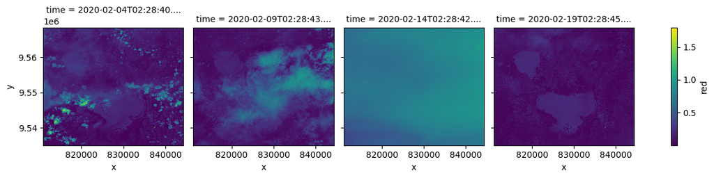

```python
# Optional

# Create a simple plot to verify that the data look reasonable
# This will load and create images from the data, which may take a few minutes
# Here we limit this plot to the first few time layers.

data.isel(time=slice(0, 4)).red.plot.imshow(col="time")
```

## Product definition

The product definition contains details on the measurements and quality layers available in the product. Datacube provides convenience functions that return this information in `pandas DataFrames`.

Use `list_measurements` to show the details for a product, and `masking.describe_variable_flags` to show the flag definitions.

```python
# Measurement definitions for the selected product
measurement_info = dc.list_measurements().loc[query['product']]
heading(f'Measurement table for product: {query["product"]}')
display(measurement_info)

# Flag definitions
flag_name = 'scl'
heading(f'Flag definition table for flag name: {flag_name}')
display(masking.describe_variable_flags(data[flag_name]))

flags_def = masking.describe_variable_flags(data[flag_name]).loc['qa']['values']
display(flags_def)
```

Measurement table for product: s2_l2a

| measurement | name | dtype | units | nodata | flags_definition | aliases | add_offset | scale_factor |
| --- | --- | --- | --- | --- | --- | --- | --- | --- |
| coastal | coastal | uint16 | 1 | 0.0 | NaN | [band_01, B01, coastal_aerosol] | -0.1 | 0.0001 |
| blue | blue | uint16 | 1 | 0.0 | NaN | [band_02, B02] | -0.1 | 0.0001 |
| green | green | uint16 | 1 | 0.0 | NaN | [band_03, B03] | -0.1 | 0.0001 |
| red | red | uint16 | 1 | 0.0 | NaN | [band_04, B04] | -0.1 | 0.0001 |
| rededge1 | rededge1 | uint16 | 1 | 0.0 | NaN | [band_05, B05, red_edge_1] | -0.1 | 0.0001 |
| rededge2 | rededge2 | uint16 | 1 | 0.0 | NaN | [band_06, B06, red_edge_2] | -0.1 | 0.0001 |
| rededge3 | rededge3 | uint16 | 1 | 0.0 | NaN | [band_07, B07, red_edge_3] | -0.1 | 0.0001 |
| nir | nir | uint16 | 1 | 0.0 | NaN | [band_08, B08, nir_1] | -0.1 | 0.0001 |
| nir08 | nir08 | uint16 | 1 | 0.0 | NaN | [band_8a, B8A, nir_2] | -0.1 | 0.0001 |
| nir09 | nir09 | uint16 | 1 | 0.0 | NaN | [band_09, B09, nir_3] | -0.1 | 0.0001 |
| swir16 | swir16 | uint16 | 1 | 0.0 | NaN | [band_11, B11, swir_1, swir_16] | -0.1 | 0.0001 |
| swir22 | swir22 | uint16 | 1 | 0.0 | NaN | [band_12, B12, swir_2, swir_22] | -0.1 | 0.0001 |
| scl | scl | uint8 | 1 | 0.0 | {'qa': {'bits': [0, 1, 2, 3, 4, 5, 6, 7], 'val... | [SCL, mask, qa] | NaN | NaN |
| aot | aot | uint16 | 1 | 0.0 | NaN | [AOT, aerosol_optical_thickness] | 0.0 | 0.0010 |
| wvp | wvp | uint16 | cm | 0.0 | NaN | [WVP, scene_average_water_vapour] | 0.0 | 0.0010 |

Flag definition table for flag name: scl

|  | bits | values | description |
| --- | --- | --- | --- |
| qa | [0, 1, 2, 3, 4, 5, 6, 7] | {'0': 'no data', '1': 'saturated or defective'... | Sen2Cor Scene Classification |

```
{'0': 'no data',
 '1': 'saturated or defective',
 '2': 'dark area pixels',
 '3': 'cloud shadows',
 '4': 'vegetation',
 '5': 'bare soils',
 '6': 'water',
 '7': 'unclassified',
 '8': 'cloud medium probability',
 '9': 'cloud high probability',
 '10': 'thin cirrus',
 '11': 'snow or ice'}
```

## Quality layer

To visualise the **SCL** layer we create a custom color map following the colors used by ESA.

Here we use `hvplot` to create a dynamic (zoom, scroll) image with an attached histogram. This example shows how a custom color map can be used with `hvplot`, as well as the [datashader aggregator](https://datashader.org/getting_started/Pipeline.html) `reductions.mode()`.

```python
# Make SCL image
# https://sentiwiki.copernicus.eu/web/s2-processing
# https://www.sentinel-hub.com/faq/how-get-s2a-scene-classification-sentinel-2/

from bokeh.models.tickers import FixedTicker

color_def = [
    (0,  '#000000', 'No data'),   # black
    (1,  '#ff0004', 'Saturated or defective'),   # red
    (2,  '#868686', 'Dark features or shadows'),   # gray
    (3,  '#774c0b', 'Cloud shadows'),   # brown
    (4,  '#10d32d', 'Vegetation'),   # green
    (5,  '#ffff53', 'Not vegetated'),   # yellow
    (6,  '#0000ff', 'Water'),   # blue
    (7,  '#818181', 'Unclassified'),   # medium gray
    (8,  '#c0c0c0', 'Cloud medium probability'),   # light gray
    (9,  '#f2f2f2', 'cloud high probability'),   # very light gray
    (10, '#53fff9', 'Thin cirrus'),   # cyan
    (11, '#ff52ff', 'Snow or ice'),   # pink
]
color_val = [x[0] for x in color_def]
color_hex = [x[1] for x in color_def]
color_txt = [f'{x[0]:2d}: {x[2]}' for x in color_def]
color_lim = (min(color_val), max(color_val) + 1)
bin_edges = color_val + [max(color_val) + 1]
bin_range = (color_val[0] + 0.5, color_val[-1] + 0.5)  # No idea why (0.5,11.5) works and (0,11) or (0,12) do not

# These options manipulate the color map and colorbar to show the categories for this product
options = {
    'title': f'Flag data for: {query["product"]} ({flag_name})',
    'cmap': color_hex,
    'clim': color_lim,
    'color_levels': bin_edges,
    'colorbar': True,
    'width': 800,
    'height': 450,
    'aspect': 'equal',
    'tools': ['hover'],
    'colorbar_opts': {
        'major_label_overrides': dict(zip(color_val, color_txt)),
        'major_label_text_align': 'left',
        'ticker': FixedTicker(ticks=color_val),
    },
}

# Set the dataset CRS, if using hvplot's projection and coastlines options
# plot_crs = native_crs
# if plot_crs == 'epsg:4326':
#     plot_crs = ccrs.PlateCarree()

# Native data and coastline overlay:
# - Comment `crs`, `projection`, `coastline` to plot in native_crs coords
# TODO: Update the axis labels to 'longitude', 'latitude' if `coastline` is used

quality_plot = data[flag_name].hvplot.image(
    x = 'x', y = 'y',                        # Dataset x,y dimension names
    rasterize = True,                        # Use Datashader
    aggregator = reductions.mode(),          # Datashader selects mode value, requires 'hv.Image'
    precompute = True,                       # Datashader precomputes what it can
    # crs = plot_crs,                          # Datset crs
    # projection = ccrs.PlateCarree(),         # Output projection (ccrs.PlateCarree() when coastline=True)
    # coastline = '10m',                       # Coastline = '10m'/'50m'/'110m'
).options(opts.Image(**options)).hist(bin_range = bin_range)

# display(quality_plot)
# Optional: Change the default time slider to a dropdown list, https://stackoverflow.com/a/54912917
fig = pn.panel(quality_plot, widgets={'time': pn.widgets.Select})  # widget_location='top_left'
fig
```

## Create and apply a good quality pixel mask

Select a set of flag values that represent "good quality" for your application. Here we select "vegetation", "not vegetated" and "water"; that is we exclude clouds and low-quality features.

The **SCL** layer uses distinct integer values to represent each class. The datacube `enum_to_bool()` function creates a boolean mask layer corresponding to a set of category values (string names).

Recall that *scale* and *offset* (if required) have already been applied by the `load_s2l2a_with_offset()` function.

```python
# Create Mask layer

good_pixel_flags = [flags_def[str(i)] for i in [4, 5, 6]]

good_pixel_mask = enum_to_bool(data[flag_name], good_pixel_flags)
display(good_pixel_mask)  # -> DataArray. Type: bool

# Apply good pixel mask (multiple layers)
good_data = data.where(good_pixel_mask).persist()
```

```
<xarray.DataArray 'enum_to_bool-68f827c3-988193cad2c62c048651607d0104a3c4' (
                                                                            time: 12,
                                                                            y: 1667,
                                                                            x: 1674)> Size: 33MB
dask.array<enum_to_bool-68f827c3, shape=(12, 1667, 1674), dtype=bool, chunksize=(1, 1667, 1674), chunktype=numpy.ndarray>
Coordinates:
  * time         (time) datetime64[ns] 96B 2020-02-04T02:28:40.772000 ... 202...
  * y            (y) float64 13kB 9.568e+06 9.568e+06 ... 9.535e+06 9.535e+06
  * x            (x) float64 13kB 8.109e+05 8.109e+05 ... 8.443e+05 8.443e+05
    spatial_ref  int32 4B 32750
Attributes:
    units:         1
    crs:           EPSG:32750
    grid_mapping:  spatial_ref
```

### Calculate NDVI

```python
# Create an NDVI layer, as useful way to visualise the data for differences in vegetation and land cover
# ndvi = (nir - red) / (nir + red)

ndvi = (good_data.nir - good_data.red) / (good_data.nir + good_data.red)
ndvi.persist()
```

```
<xarray.DataArray (time: 12, y: 1667, x: 1674)> Size: 134MB
dask.array<truediv, shape=(12, 1667, 1674), dtype=float32, chunksize=(1, 1667, 1674), chunktype=numpy.ndarray>
Coordinates:
  * time         (time) datetime64[ns] 96B 2020-02-04T02:28:40.772000 ... 202...
  * y            (y) float64 13kB 9.568e+06 9.568e+06 ... 9.535e+06 9.535e+06
  * x            (x) float64 13kB 8.109e+05 8.109e+05 ... 8.443e+05 8.443e+05
    spatial_ref  int32 4B 32750
```

## Plot and browse the data

There are numerous tools we can use to plot and interact with the data. Here we use `hvplot` again because it works well with dask and allows us to zoom and scroll quite efficiently. `Hvplot` uses [Datashader](https://datashader.org/getting_started/Pipeline.html) to process and render only the pixels that are required for the viewport.

Various options can be changed such as the data layer, colour map and colour range.

```python
# Generate a plot

options = {
    'title': f'{query["product"]}',
    'width': 800,
    'height': 450,
    'aspect': 'equal',
    'cmap': cc.rainbow,
    'clim': (0, 1),                          # Limit the color range depending on the layer_name
    'colorbar': True,
    'tools': ['hover'],
}

# Set the dataset CRS, if using hvplot's projection and coastlines options
# plot_crs = native_crs
# if plot_crs == 'epsg:4326':
#     plot_crs = ccrs.PlateCarree()

# Native data and coastline overlay:
# - Comment `crs`, `projection`, `coastline` to plot in native_crs coords
# TODO: Update the axis labels to 'longitude', 'latitude' if `coastline` is used

layer_plot = ndvi.hvplot.image(
    x = 'x', y = 'y',                        # Dataset x,y dimension names
    rasterize = True,                        # Use Datashader
    aggregator = reductions.mean(),          # Datashader selects mean value
    precompute = True,                       # Datashader precomputes what it can
    # crs = plot_crs,                        # Dataset crs
    # projection = ccrs.PlateCarree(),         # Output projection (use ccrs.PlateCarree() when coastline=True)
    # coastline='10m',                         # Coastline = '10m'/'50m'/'110m'
).options(opts.Image(**options)).hist(bin_range = options['clim'])

# display(layer_plot)
# Optional: Change the default time slider to a dropdown list, https://stackoverflow.com/a/54912917
fig = pn.panel(layer_plot, widgets={'time': pn.widgets.Select})  # widget_location='top_left'
display(fig)
```